# Assignment5

Yuanyuan Pan

October 30, 2016

This assignment helps understanding estimation and inference for simple linear regression This assignment is individual

## 1 Method 1

### 1.1 Project data

Analyze the second case data from file `ResidualAnalysisProjectData_2.csv`. Download the data.

```r
#LinearModel.Case2<-read.csv(file=paste(datapath,"ResidualAnalysisProjectData_2.csv",sep="/"),header=TRUE,sep=",")
dat<-read.csv("ResidualAnalysisProjectData_2.csv",header=TRUE,sep=",")
head(dat)
```

```
##      Input      Output
## 1 3.132859  4.17792255
## 2 5.561134  5.84669919
## 3 1.984543 -0.09834184
## 4 5.619160  7.84692946
## 5 6.378149  7.57941491
## 6 6.123204  5.68973137
```

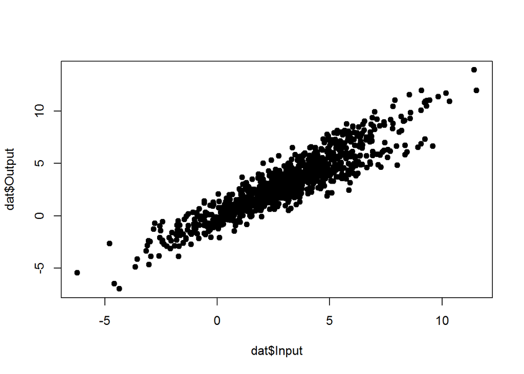

```r
plot(dat$Input,dat$Output, type="p",pch=19)
```

```r
nSample<-length(dat$Input)
```

### 1.2 Estimate linear model

Fit linear model to the data and plot the sample and the fitted values.

```r
#Estimated.Linear.Model.Case2<-lm(Output~Input,LinearModel.Case2)
m1<-lm(Output~Input,dat)
m1$coefficients
```

```
## (Intercept)       Input
## -0.03657717  1.03270579
```

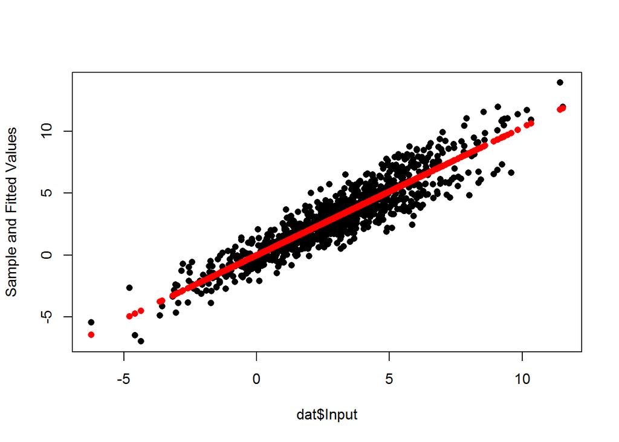

```r
matplot(dat$Input,cbind(dat$Output,m1$fitted.values),type="p",pch=16,ylab="Sample and Fitted Values")
```

```r
summary(m1)
```

```
##
## Call:
## lm(formula = Output ~ Input, data = dat)
##
## Residuals:
##     Min      1Q  Median      3Q     Max
## -3.5620 -0.7987  0.0267  0.7870  3.0759
##
## Coefficients:
##             Estimate Std. Error t value Pr(>|t|)
## (Intercept) -0.03658    0.05718   -0.64    0.523
## Input        1.03271    0.01453   71.06   <2e-16 ***
## ---
## Signif. codes:  0 '***' 0.001 '**' 0.01 '*' 0.05 '.' 0.1 ' ' 1
##
## Residual standard error: 1.157 on 998 degrees of freedom
## Multiple R-squared:  0.835,  Adjusted R-squared:  0.8348
## F-statistic:  5050 on 1 and 998 DF,  p-value: < 2.2e-16
```

From the summary we can see the P-value of intercept is too large, there could be something wrong with the residuals

Analize the residuals, plot the the residuals and their probability density function.

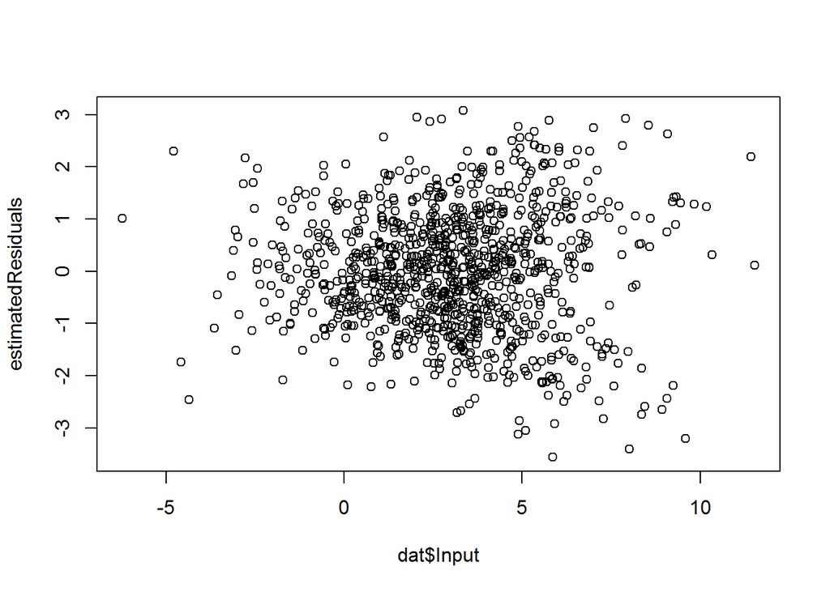

```r
#EstimatedResiduals.Case2<-Estimated.Linear.Model.Case2$residuals
estimatedResiduals<-m1$residuals
plot(dat$Input,estimatedResiduals)
```

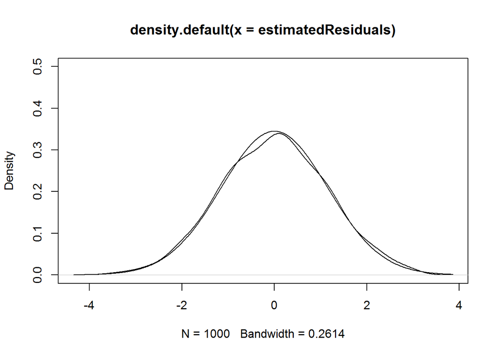

```r
Probability.Density.Residuals<-density(estimatedResiduals)
plot(Probability.Density.Residuals,ylim=c(0,.5))
lines(Probability.Density.Residuals$x,
      dnorm(Probability.Density.Residuals$x,mean=mean(estimatedResiduals),sd=sd(estimatedResiduals)))
```

From the residuals plots we can see there could be two ramdom number resources. One with larger mean and smaller standard error. And the narrow one is contained within the other one.

### 1.3 Creating training sample for separation of mixed models

Create training sample with `Input >= 5` and separate the points above the fitted line and below.

```r
# Create NA vectors
Train.Sample<-data.frame(trainInput=dat$Input,trainOutput=rep(NA,nSample))
Train.Sample.Steeper<-data.frame(trainSteepInput=dat$Input,
                                       trainSteepOutput=rep(NA,nSample))
Train.Sample.Flatter<-data.frame(trainFlatInput=dat$Input,
                                       trainFlatOutput=rep(NA,nSample))
```

```r
head(cbind(dat,
           Train.Sample,
           Train.Sample.Steeper,
           Train.Sample.Flatter))
```

```
##      Input      Output trainInput trainOutput trainSteepInput
## 1 3.132859  4.17792255   3.132859          NA        3.132859
## 2 5.561134  5.84669919   5.561134          NA        5.561134
## 3 1.984543 -0.09834184   1.984543          NA        1.984543
## 4 5.619160  7.84692946   5.619160          NA        5.619160
## 5 6.378149  7.57941491   6.378149          NA        6.378149
## 6 6.123204  5.68973137   6.123204          NA        6.123204
##   trainSteepOutput trainFlatInput trainFlatOutput
## 1               NA       3.132859              NA
## 2               NA       5.561134              NA
## 3               NA       1.984543              NA
## 4               NA       5.619160              NA
## 5               NA       6.378149              NA
## 6               NA       6.123204              NA
```

Select parts of the sample with `Input` greater than 5 and `Output` either above the estimated regression line or below it.

```r
# Create selectors
Train.Sample.Selector<-dat$Input>=5
Train.Sample.Steeper.Selector<-Train.Sample.Selector&
  (dat$Output>m1$fitted.values)
Train.Sample.Flatter.Selector<-Train.Sample.Selector&
  (dat$Output<=m1$fitted.values)
```

Create training samples for steep and flat slopes.

```r
# Select subsamples
Train.Sample[Train.Sample.Selector,2]<-dat[Train.Sample.Selector,2]
Train.Sample.Steeper[Train.Sample.Steeper.Selector,2]<-dat[Train.Sample.Steeper.Selector,2]
Train.Sample.Flatter[Train.Sample.Flatter.Selector,2]<-dat[Train.Sample.Flatter.Selector,2]
head(Train.Sample)
```

```
##   trainInput trainOutput
## 1   3.132859          NA
## 2   5.561134    5.846699
## 3   1.984543          NA
## 4   5.619160    7.846929
## 5   6.378149    7.579415
## 6   6.123204    5.689731
```

Data frame `Train.Sample` satisfies condition `dat$Input>=5`. Check what are the resulting training samples.

```r
head(cbind(dat,
           Train.Sample,
           Train.Sample.Steeper,
           Train.Sample.Flatter),10)
```

```
##        Input      Output trainInput trainOutput trainSteepInput
## 1  3.1328589  4.17792255  3.1328589          NA       3.1328589
## 2  5.5611337  5.84669919  5.5611337    5.846699       5.5611337
## 3  1.9845429 -0.09834184  1.9845429          NA       1.9845429
## 4  5.6191601  7.84692946  5.6191601    7.846929       5.6191601
## 5  6.3781486  7.57941491  6.3781486    7.579415       6.3781486
## 6  6.1232040  5.68973137  6.1232040    5.689731       6.1232040
## 7  0.7666195 -1.45675560  0.7666195          NA       0.7666195
## 8  4.3535141  4.16746077  4.3535141          NA       4.3535141
## 9  2.3627156  2.38611901  2.3627156          NA       2.3627156
## 10 6.3272368  6.77354738  6.3272368    6.773547       6.3272368
##    trainSteepOutput trainFlatInput trainFlatOutput
## 1                NA      3.1328589              NA
## 2          5.846699      5.5611337              NA
## 3                NA      1.9845429              NA
## 4          7.846929      5.6191601              NA
## 5          7.579415      6.3781486              NA
## 6                NA      6.1232040        5.689731
## 7                NA      0.7666195              NA
## 8                NA      4.3535141              NA
## 9                NA      2.3627156              NA
## 10         6.773547      6.3272368              NA
```

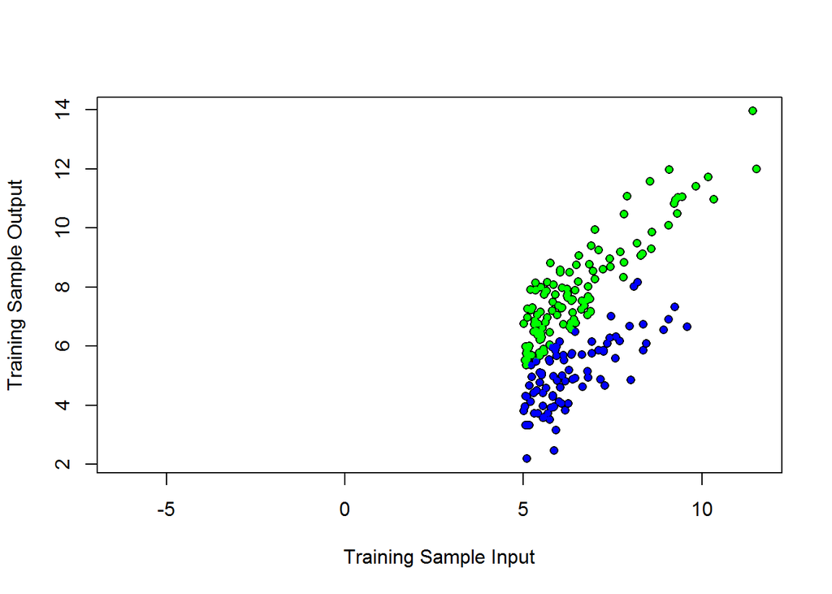

```r
plot(Train.Sample$trainInput,Train.Sample$trainOutput,pch=16,ylab="Training Sample Output",
     xlab="Training Sample Input")
points(Train.Sample.Steeper$trainSteepInput,Train.Sample.Steeper$trainSteepOutput,pch=20,col="green")
points(Train.Sample.Flatter$trainFlatInput,Train.Sample.Flatter$trainFlatOutput,pch=20,col="blue")
```

### 1.4 Fit linear models to train samples

Fit linear models to both training samples, interpret the summaries of both models.

```r
Train.Sample.Flat.lm <- lm(trainFlatOutput~trainFlatInput, data = Train.Sample.Flatter)
Train.Sample.Steep.lm <- lm(trainSteepOutput~trainSteepInput, data = Train.Sample.Steeper)
summary(Train.Sample.Steep.lm)$coefficients
```

```
##                 Estimate Std. Error  t value     Pr(>|t|)
## (Intercept)     1.021798 0.33271502  3.07109 2.647868e-03
## trainSteepInput 1.048763 0.04981059 21.05503 8.979480e-42
```

```r
summary(Train.Sample.Steep.lm)$sigma
```

```
## [1] 0.7800507
```

```r
summary(Train.Sample.Steep.lm)$df
```

```
## [1]   2 118   2
```

```r
summary(Train.Sample.Steep.lm)$r.squared
```

```
## [1] 0.7897791
```

```r
summary(Train.Sample.Steep.lm)$adj.r.squared
```

```
## [1] 0.7879975
```

```r
summary(Train.Sample.Steep.lm)$fstatistic
```

```
##    value    numdf    dendf
## 443.3142   1.0000 118.0000
```

```r
summary(Train.Sample.Flat.lm)$coefficients
```

```
##                  Estimate Std. Error   t value     Pr(>|t|)
## (Intercept)    0.08316391 0.50585815 0.1644016 8.698008e-01
## trainFlatInput 0.77825624 0.07855636 9.9069789 7.031944e-16
```

```r
summary(Train.Sample.Flat.lm)$sigma
```

```
## [1] 0.8072447
```

```r
summary(Train.Sample.Flat.lm)$df
```

```
## [1]  2 86  2
```

```r
summary(Train.Sample.Flat.lm)$r.squared
```

```
## [1] 0.5329849
```

```r
summary(Train.Sample.Flat.lm)$adj.r.squared
```

```
## [1] 0.5275545
```

```r
summary(Train.Sample.Flat.lm)$fstatistic
```

```
##    value    numdf    dendf
## 98.14823  1.00000 86.00000
```

Print out the coefficients of both models for the training sample.

```r
rbind(Steeper.Coefficients=Train.Sample.Steep.lm$coefficients,
      Flatter.Coefficients=Train.Sample.Flat.lm$coefficients)
```

```
##                      (Intercept) trainSteepInput
## Steeper.Coefficients  1.02179775       1.0487634
## Flatter.Coefficients  0.08316391       0.7782562
```

Plot the entire sample with the fitted regression lines estimated from both training subsamples.

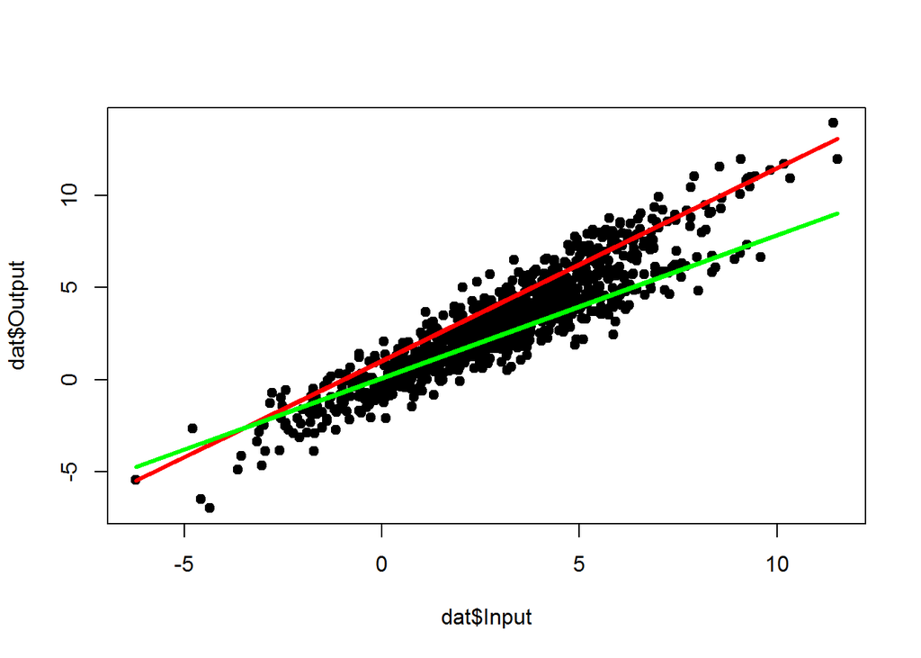

```r
plot(dat$Input,dat$Output, type="p",pch=19)
lines(dat$Input,predict(Train.Sample.Steep.lm,
                        data.frame(trainSteepInput=dat$Input),
                        interval="prediction")[,1],col="red",lwd=3)
lines(dat$Input,predict(Train.Sample.Flat.lm,data.frame(trainFlatInput=dat$Input),
                        interval="prediction")[,1],col="green",lwd=3)
```

Separate the entire sample using the estimated train linear models. Define distances from each point to both regression lines.

```r
# Define the distances from each Output point to both estimated training lines
Distances.to.Steeper<-abs(dat$Output-
                            dat$Input*Train.Sample.Steep.lm$coefficients[2]-
                            Train.Sample.Steep.lm$coefficients[1])
Distances.to.Flatter<-abs(dat$Output-
                           dat$Input*Train.Sample.Flat.lm$coefficients[2]-
                           Train.Sample.Flat.lm$coefficients[1])
```

Define separating sequence which equals TRUE if observation belongs to model with steeper slope and FALSE otherwise.

```r
# Define the unscramble sequence
Unscrambling.Sequence.Steeper<-Distances.to.Steeper<Distances.to.Flatter
```

Separate the sample into steeper and flatter parts. Create data frames.

```r
# Define  two subsamples with NAs in the Output columns
Subsample.Steeper<-data.frame(steeperInput=dat$Input,steeperOutput=rep(NA,nSample))
Subsample.Flatter<-data.frame(flatterInput=dat$Input,flatterOutput=rep(NA,nSample))
```

Fill in the data frames.

```r
# Fill in the unscrambled outputs instead of NAs where necessary
Subsample.Steeper[Unscrambling.Sequence.Steeper,2]<-dat[Unscrambling.Sequence.Steeper,2]
Subsample.Flatter[!Unscrambling.Sequence.Steeper,2]<-dat[!Unscrambling.Sequence.Steeper,2]

# Check the first rows
head(cbind(dat,Subsample.Steeper,Subsample.Flatter))
```

```
##      Input      Output steeperInput steeperOutput flatterInput
## 1 3.132859  4.17792255     3.132859      4.177923     3.132859
## 2 5.561134  5.84669919     5.561134      5.846699     5.561134
## 3 1.984543 -0.09834184     1.984543            NA     1.984543
## 4 5.619160  7.84692946     5.619160      7.846929     5.619160
## 5 6.378149  7.57941491     6.378149      7.579415     6.378149
## 6 6.123204  5.68973137     6.123204            NA     6.123204
##   flatterOutput
## 1            NA
## 2            NA
## 3   -0.09834184
## 4            NA
## 5            NA
## 6    5.68973137
```

plot the two samples

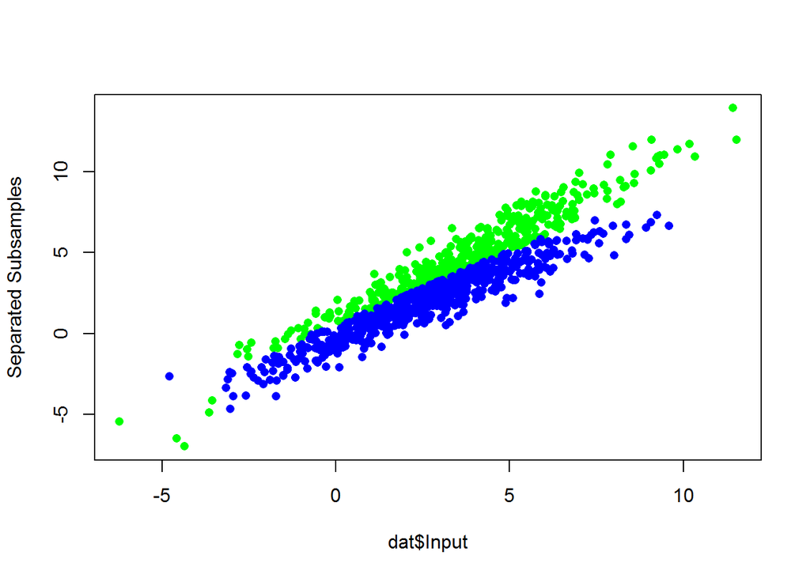

```r
# Plot the unscrambled subsamples, include the original entire sample as a check
matplot(dat$Input,cbind(dat$Output,
                        Subsample.Steeper$steeperOutput,
                        Subsample.Flatter$flatterOutput),
        type="p",col=c("black","green","blue"),
        pch=16,ylab="Separated Subsamples")
```

```r
# Mixing Probability Of Steeper Slope
(Mixing.Probability.Of.Steeper.Slope<-sum(Unscrambling.Sequence.Steeper)/length(Unscrambling.Sequence.Steeper))
```

```
## [1] 0.417
```

```r
binom.test(sum(Unscrambling.Sequence.Steeper),nSample, p =0.5, alternative = "two.sided")
```

```
##
##  Exact binomial test
##
## data:  sum(Unscrambling.Sequence.Steeper) and nSample
## number of successes = 417, number of trials = 1000, p-value =
## 1.702e-07
## alternative hypothesis: true probability of success is not equal to 0.5
## 95 percent confidence interval:
##  0.3862231 0.4482670
## sample estimates:
## probability of success
##                  0.417
```

### 1.5 Fitting the models to seperated samples

```r
Linear.Model.Steeper.Recovered <- lm(steeperOutput ~ steeperInput, data = Subsample.Steeper)
Linear.Model.Flatter.Recovered <- lm(flatterOutput ~ flatterInput, data = Subsample.Flatter)
rbind(Steeper.Coefficients=Linear.Model.Steeper.Recovered$coefficients,
      Flatter.Coefficients=Linear.Model.Flatter.Recovered$coefficients)
```

```
##                      (Intercept) steeperInput
## Steeper.Coefficients   0.9325475    1.0517077
## Flatter.Coefficients  -0.3467106    0.8630519
```

```r
summary(Linear.Model.Steeper.Recovered)$r.sq
```

```
## [1] 0.9365043
```

```r
summary(Linear.Model.Flatter.Recovered)$r.sq
```

```
## [1] 0.902158
```

```r
#1.6 Analyze the residuals
# Plot residuals
matplot(dat$Input,cbind(c(summary(Linear.Model.Steeper.Recovered)$residuals,
                         summary(Linear.Model.Flatter.Recovered)$residuals),
                       estimatedResiduals),type="p",pch=c(19,16),ylab="Residuals before and after unscrambling")
legend("bottomleft",legend=c("Before","After"),col=c("red","black"),pch=16)

# Estimate standard deviations
unmixedResiduals<-c(summary(Linear.Model.Steeper.Recovered)$residuals,
                                   summary(Linear.Model.Flatter.Recovered)$residuals)
apply(cbind(ResidualsAfter=unmixedResiduals,
           ResidualsBefore=estimatedResiduals),2,sd)
```

```
##  ResidualsAfter ResidualsBefore
##       0.6863947       1.1564568
```

```r
suppressWarnings(library(fitdistrplus))
```

[figure not shown]

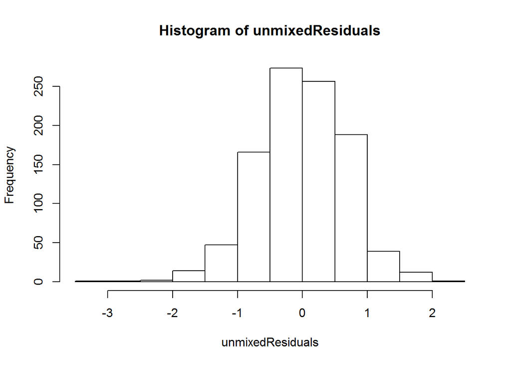

```r
hist(unmixedResiduals)
```

```r
(residualsParam<-fitdistr(unmixedResiduals,"normal"))
```

```
##        mean            sd
##   3.242171e-18   6.860514e-01
##  (2.169485e-02) (1.534058e-02)
```

```r
ks.test(unmixedResiduals,"pnorm",residualsParam$estimate[1],residualsParam$estimate[2])
```

```
##
##  One-sample Kolmogorov-Smirnov test
##
## data:  unmixedResiduals
## D = 0.023344, p-value = 0.6471
## alternative hypothesis: two-sided
```

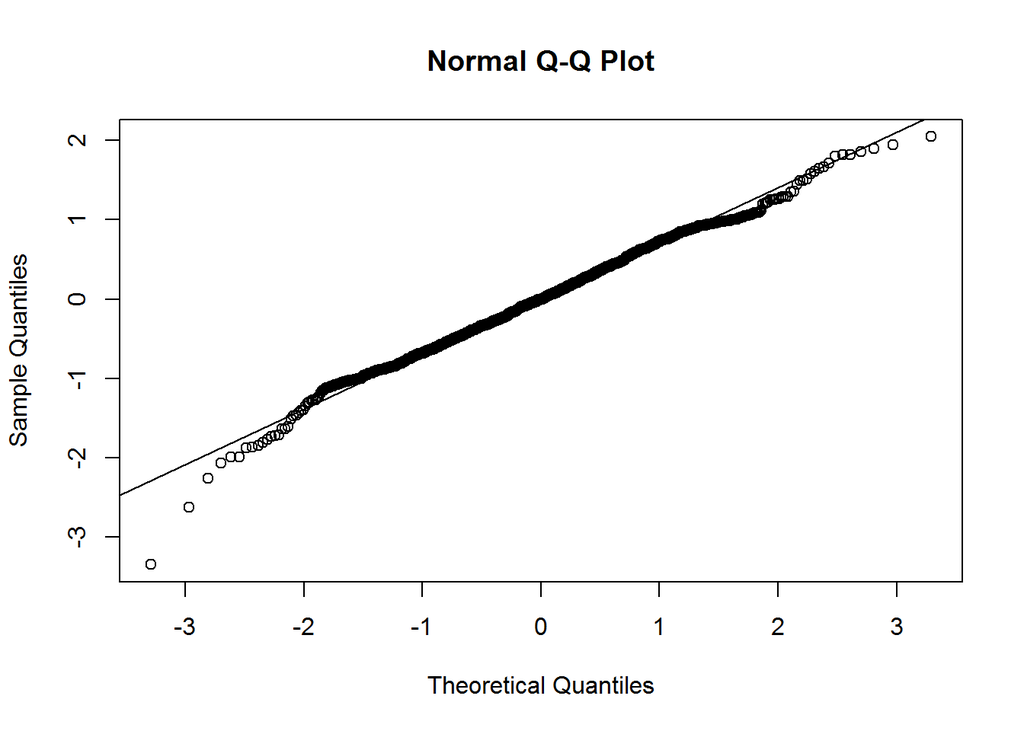

```r
qqnorm(unmixedResiduals)
qqline(unmixedResiduals)
```

```r
# Slopes
c(Steeper.SLope=Linear.Model.Steeper.Recovered$coefficients[2],Flatter.Slope=Linear.Model.Flatter.Recovered$coefficients[2])
```

```
## Steeper.SLope.steeperInput Flatter.Slope.flatterInput
##                  1.0517077                  0.8630519
```

```r
# Intercepts
c(Steeper.Intercept=Linear.Model.Steeper.Recovered$coefficients[1],Flatter.Intercept=Linear.Model.Flatter.Recovered$coefficients[1])
```

```
## Steeper.Intercept.(Intercept) Flatter.Intercept.(Intercept)
##                     0.9325475                    -0.3467106
```

## 2 Alternative Method Based on Volatility Clustering

If the sample is $<y_1,\ldots,y_n>$ then estimate of variance is built by averaging terms $(y_i - \bar{y})^2$ as
$$\hat{\sigma}^2 = \frac{1}{n-1}\sum_{i=1}^n (y_i - \bar{y})^2.$$
Make a plot of squared deviations $z_i=(y_i - \bar{y})^2$.

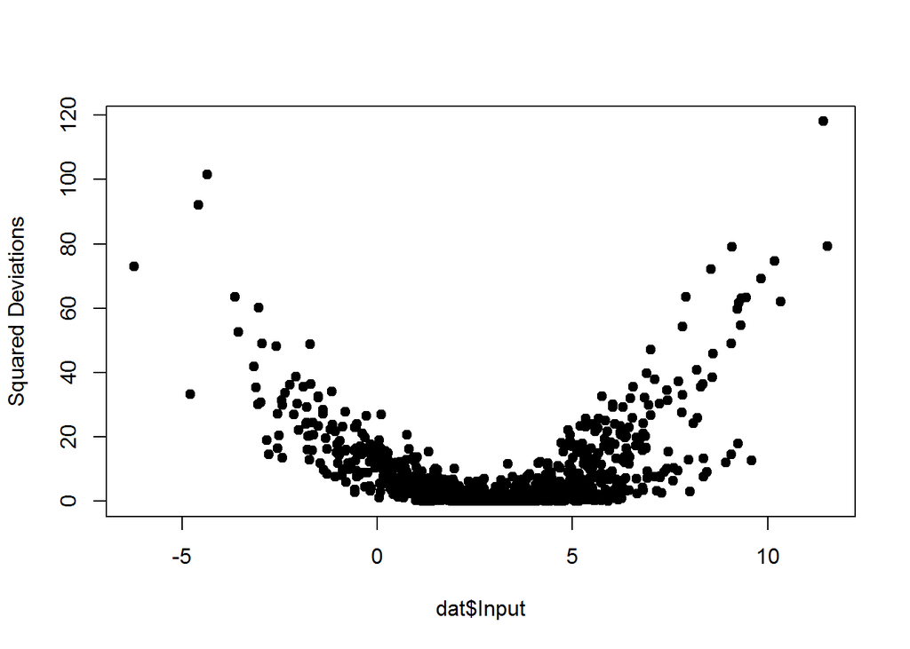

```r
plot(dat$Input,(dat$Output-mean(dat$Output))^2, type="p",pch=19,
     ylab="Squared Deviations")
```

Hint. Find $\bar{y}$ using model expression
$$y_i = \beta_0 + \beta_1 x_i + \epsilon_i.$$
Then substitute $\hat{\beta}_0,~\hat{\beta_1}$ estimated by linear model and form $(y_i-\bar{y})^2$